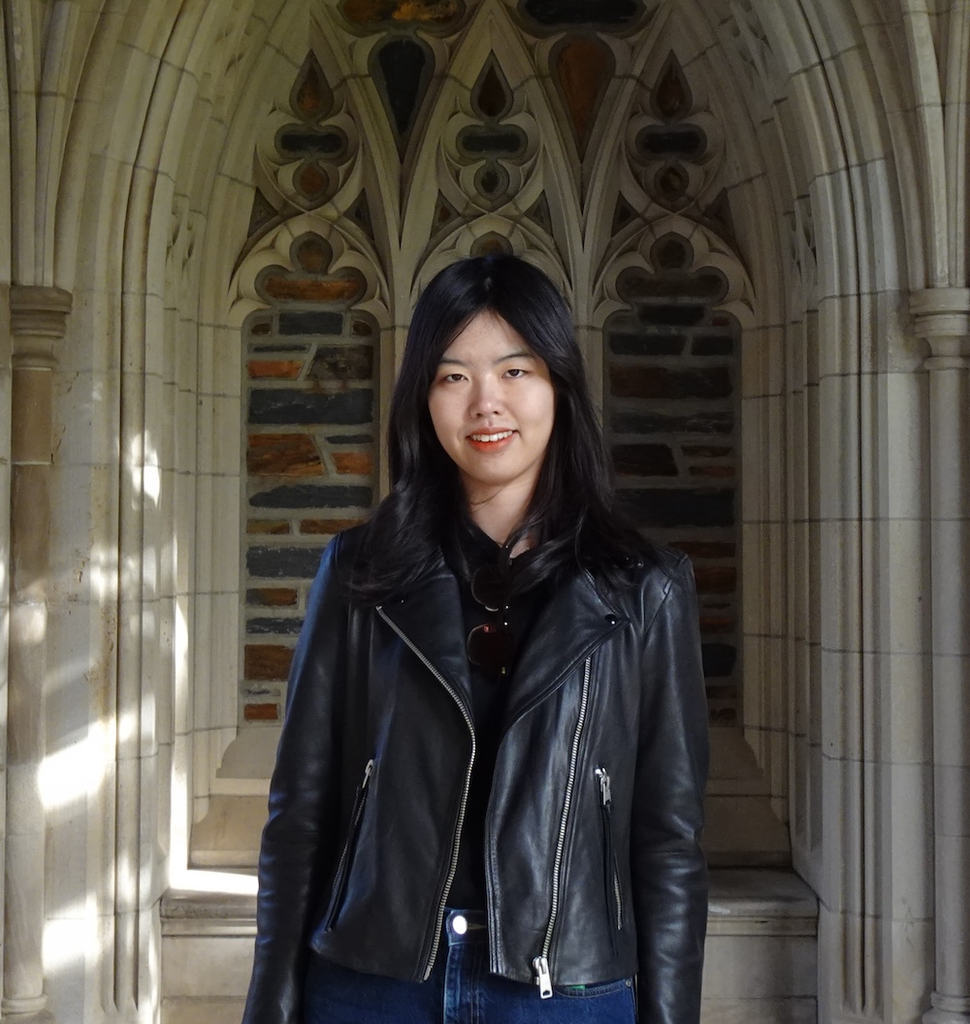

# Yunyi Ru

## Biography

Yunyi Ru is a 2nd year master’s student in the Molecular Microbiology and Immunology department of [Johns Hopkins Bloomberg School of Public Health](https://publichealth.jhu.edu/).

Yunyi currently works as a graduate student researcher at [The Pekosz Lab](https://pekoszlab.com/) on *virology*, and a research assistant at [R3ISE Center](https://publichealth.jhu.edu/the-r3-center-for-innovation-in-science-education) on *responsive science communication*.

## Education

**Johns Hopkins University** | Baltimore, MD

ScM in Molecular Microbiology and Immunology | August 2023 - May 2025

**Duke Kunshan University/Duke University** | Kunshan, China/Durham, NC

B.S. in Cell and Molecular Biology (Dual Degree) | August 2019 - May 2023

## Experience

#### Research

**[The Pekosz Lab](https://pekoszlab.com/), Johns Hopkins University** | *Graduate Student Researcher* | October 2023 - Present

- Isolated and characterized lab-adapted and circulating respiratory syncytial virus using various molecular biology and genetics methods.

**[The Lin Lab](https://yajuanlin.github.io/), Duke Kunshan University** | *Undergraduate Student Researcher* | October 2021 - May 2023

- Monitored and analyzed changes in antibiotic resistance gene prevalence in a local shallow lake over the year.

**[iGEM Competition 2022](https://2022.igem.wiki/dku/index.html), Duke Kunshan University** | *Team Leader* | December 2021 - October 2022

- Designed an engineered bacteria strain by molecular cloning and protein expression.

**Global Health Resource Center, Duke Kunshan University** | *Undergraduate Student Researcher* | August 2020 - December 2020

- Conducted surveys and interviews to assess the current situation of chronic disease management and control in 4 local communities.

#### Others

**[R3ISE Center](https://publichealth.jhu.edu/the-r3-center-for-innovation-in-science-education), Johns Hopkins University** | *Research Assistant* | October 2023 - Present

- Initiated the ‘R3 Read Today’ project by selecting and presenting content on important topics related to responsible scientific practices for science communication on [X](https://twitter.com/R3_JHSPH) and [Instagram](https://www.instagram.com/r3_jhsph/).

**Academic Resource Center, Duke Kunshan University** | *Teaching Assistant* | October 2021 - December 2021

**HOB Biotech Group Suzhou Co., Ltd** | *R&D Intern* | July 2021 - August 2021

**Intramural Global Health Case Competition, Duke Kunshan University** | *Team Leader* | March 2021

**Crystal Pharmatech Co., Ltd** | *R&D Intern* | May 2020 - June 2020

## Resume

[figure not shown]

## Fun Fact

Yunyi is a fan of alt/indie music and enjoys playing the electric guitar in her free time.

*This page is built with postcards.*